# Fraud detection

**WARNING**: this notebook relies on several **R packages**. Whenever one is called (for instance via a call such as “*library(torch)*”), this implies that the package has been installed, e.g., via “*install.packages(”torch”)*”. Hence, make sure the following packages are installed!

```r
# install.packages("tidyverse")
# install.packages(c("data.table", "fastDummies", "lightgbm", "reticulate", "keras"))
```

**NOTE**: in **data science**, one of the most crucial competence is **domain knowledge**.  
Data is key (more than any algorithm) and domain knowledge helps understand how it is built and which features are likely to matter most.

# Introduction

## Principles

Quite obviously, the purpose of fraud detection is to **identify illicit transactions**.  
This is usually done via the characteristics of the transaction, which can be split into several categories: the nature of the transaction (e.g., type (credit card versus online), location, timing or amount), and the properties of the parties: history of transactions, location, gender of emitter, trustworthiness of receiver, etc.

Hence, like for credit risk, the main task will be essentially **classification** (supervised learning), where we use the characteristics of the transactions to predict if they are fraudulent or not. However, with fraud data, the imbalance is even more pronounced, because usually less than 1% of transactions are tagged as fraudulent. This means that most of the interesting information comes from a very small portion of the data!

Note that fraud is widespread and affects, many domains, especially insurance for instance (see Section 6 of [this paper](https://www.sciencedirect.com/science/article/abs/pii/S1084804516300571) for examples). The tools to detect fraud (or anomalies) in other context are quite similar (supervised learning).

## Short list of **free** references

There are several books available on the topic, but the following one, with code snippets in python is probably the most applied (with PyTorch examples to illustrate neural networks):  
- [Reproducible Machine Learning for Credit Card Fraud detection - Practical handbook](https://fraud-detection-handbook.github.io/fraud-detection-handbook/Foreword.html)

Two recent survey articles:

- [Survey of Credit Card Anomaly and Fraud Detection Using Sampling Techniques](https://www.mdpi.com/2079-9292/11/23/4003/pdf) (2022)
- [Financial Fraud: A Review of Anomaly Detection Techniques and Recent Advances](https://www.sciencedirect.com/science/article/pii/S0957417421017164) (2022)

# Data wrangling

First, let us load the data & the packages.  
The data originates from a [**Kaggle competition**](https://www.kaggle.com/datasets/kartik2112/fraud-detection) and we only keep the training data for which the target/label is available.  
The file is also available on this [**drive link**](https://drive.google.com/file/d/152rvWvzXwju1tXJzoIoBkcxt7Zs6TDBM/view?usp=sharing).  
$\rightarrow$ Please download it and place it in the same folder as the notebook.

```r
library(tidyverse)
library(data.table)         # To import csv sheets rapidly
library(fastDummies)        # For dummies
library(RhpcBLASctl)        # For multi-threading
fraud <- fread("fraud.csv")
head(fraud)
```

| V1 | trans_date_trans_time | cc_num | merchant | category | amt | first | last | gender | street | city | state | zip | lat | long | city_pop | job | dob | trans_num | unix_time | merch_lat | merch_long | is_fraud |
| --- | --- | --- | --- | --- | --- | --- | --- | --- | --- | --- | --- | --- | --- | --- | --- | --- | --- | --- | --- | --- | --- | --- |
| 0 | 2019-01-01 00:00:18 | 2703186189652095 | fraud_Rippin, Kub and Mann | misc_net | 4.97 | Jennifer | Banks | F | 561 Perry Cove | Moravian Falls | NC | 28654 | 36.0788 | -81.1781 | 3495 | Psychologist, counselling | 1988-03-09 | 0b242abb623afc578575680df30655b9 | 1325376018 | 36.01129 | -82.04832 | 0 |
| 1 | 2019-01-01 00:00:44 | 630423337322 | fraud_Heller, Gutmann and Zieme | grocery_pos | 107.23 | Stephanie | Gill | F | 43039 Riley Greens Suite 393 | Orient | WA | 99160 | 48.8878 | -118.2105 | 149 | Special educational needs teacher | 1978-06-21 | 1f76529f8574734946361c461b024d99 | 1325376044 | 49.15905 | -118.18646 | 0 |
| 2 | 2019-01-01 00:00:51 | 38859492057661 | fraud_Lind-Buckridge | entertainment | 220.11 | Edward | Sanchez | M | 594 White Dale Suite 530 | Malad City | ID | 83252 | 42.1808 | -112.2620 | 4154 | Nature conservation officer | 1962-01-19 | a1a22d70485983eac12b5b88dad1cf95 | 1325376051 | 43.15070 | -112.15448 | 0 |
| 3 | 2019-01-01 00:01:16 | 3534093764340240 | fraud_Kutch, Hermiston and Farrell | gas_transport | 45.00 | Jeremy | White | M | 9443 Cynthia Court Apt. 038 | Boulder | MT | 59632 | 46.2306 | -112.1138 | 1939 | Patent attorney | 1967-01-12 | 6b849c168bdad6f867558c3793159a81 | 1325376076 | 47.03433 | -112.56107 | 0 |
| 4 | 2019-01-01 00:03:06 | 375534208663984 | fraud_Keeling-Crist | misc_pos | 41.96 | Tyler | Garcia | M | 408 Bradley Rest | Doe Hill | VA | 24433 | 38.4207 | -79.4629 | 99 | Dance movement psychotherapist | 1986-03-28 | a41d7549acf90789359a9aa5346dcb46 | 1325376186 | 38.67500 | -78.63246 | 0 |
| 5 | 2019-01-01 00:04:08 | 4767265376804500 | fraud_Stroman, Hudson and Erdman | gas_transport | 94.63 | Jennifer | Conner | F | 4655 David Island | Dublin | PA | 18917 | 40.3750 | -75.2045 | 2158 | Transport planner | 1961-06-19 | 189a841a0a8ba03058526bcfe566aab5 | 1325376248 | 40.65338 | -76.15267 | 0 |

The first three columns probably won’t be very useful (this is a shortcut though: time can be predictive, but it would need to be transformed, e.g., into days and hours).  
The merchant name can also be improved.

```r
fraud <- fraud[, -(1:3)]                 # Removing the first 3 columns (not useful)
fraud <- fraud |>
  select(-trans_num, -first, -last) |>   # Remove 3 other columns
  mutate(merchant = merchant |> str_remove("fraud_"))
fraud |> head(4)                         # Show first 4 rows
```

| merchant | category | amt | gender | street | city | state | zip | lat | long | city_pop | job | dob | unix_time | merch_lat | merch_long | is_fraud |
| --- | --- | --- | --- | --- | --- | --- | --- | --- | --- | --- | --- | --- | --- | --- | --- | --- |
| Rippin, Kub and Mann | misc_net | 4.97 | F | 561 Perry Cove | Moravian Falls | NC | 28654 | 36.0788 | -81.1781 | 3495 | Psychologist, counselling | 1988-03-09 | 1325376018 | 36.01129 | -82.04832 | 0 |
| Heller, Gutmann and Zieme | grocery_pos | 107.23 | F | 43039 Riley Greens Suite 393 | Orient | WA | 99160 | 48.8878 | -118.2105 | 149 | Special educational needs teacher | 1978-06-21 | 1325376044 | 49.15905 | -118.18646 | 0 |
| Lind-Buckridge | entertainment | 220.11 | M | 594 White Dale Suite 530 | Malad City | ID | 83252 | 42.1808 | -112.2620 | 4154 | Nature conservation officer | 1962-01-19 | 1325376051 | 43.15070 | -112.15448 | 0 |
| Kutch, Hermiston and Farrell | gas_transport | 45.00 | M | 9443 Cynthia Court Apt. 038 | Boulder | MT | 59632 | 46.2306 | -112.1138 | 1939 | Patent attorney | 1967-01-12 | 1325376076 | 47.03433 | -112.56107 | 0 |

There remains a lot to do… There are too many merchants and cities and for simplicity, we choose to remove them. Instead, we’ll keep categories, which we will transform via **one-hot encoding**: each categorical value is coded into a new binary column (see below).  
In terms of locations, zip is a number but can be misleading, so we’ll only keep latitude & longitude.  
**NOTE**: the one-hot encoding below can *take some time*…

```r
fraud <- fraud |>                        # Below we remove yet other columns
  select(-merchant, -street, -city, -state, -zip, -dob, -unix_time, -job) |>
  mutate(gender = gender |> as.factor() |> as.numeric())
dummy_cat <- dummy_cols(fraud$category)  # One-hot encoding
fraud <- fraud |>
  select(-category) |>                   # Removes the "category" column
  bind_cols(dummy_cat |> select(-1))     # Adds the equivalent dummy columns
fraud |> head(3)
```

| amt | gender | lat | long | city_pop | merch_lat | merch_long | is_fraud | .data_entertainment | .data_food_dining | .data_gas_transport | .data_grocery_net | .data_grocery_pos | .data_health_fitness | .data_home | .data_kids_pets | .data_misc_net | .data_misc_pos | .data_personal_care | .data_shopping_net | .data_shopping_pos | .data_travel |
| --- | --- | --- | --- | --- | --- | --- | --- | --- | --- | --- | --- | --- | --- | --- | --- | --- | --- | --- | --- | --- | --- |
| 4.97 | 1 | 36.0788 | -81.1781 | 3495 | 36.01129 | -82.04832 | 0 | 0 | 0 | 0 | 0 | 0 | 0 | 0 | 0 | 1 | 0 | 0 | 0 | 0 | 0 |
| 107.23 | 1 | 48.8878 | -118.2105 | 149 | 49.15905 | -118.18646 | 0 | 0 | 0 | 0 | 0 | 1 | 0 | 0 | 0 | 0 | 0 | 0 | 0 | 0 | 0 |
| 220.11 | 2 | 42.1808 | -112.2620 | 4154 | 43.15070 | -112.15448 | 0 | 1 | 0 | 0 | 0 | 0 | 0 | 0 | 0 | 0 | 0 | 0 | 0 | 0 | 0 |

Before the models, let’s evaluate the **imbalance** of the data…

```r
mean(fraud$is_fraud)
```

```
[1] 0.005788652
```

0.6% of positive cases: this is very low. Again: a large chunk of the information seems to be contained in a very small fraction of observations…

# A first lightGBM model

## Data splitting

In this section, we fit a boosted tree from the [lightGBM](https://lightgbm.readthedocs.io/en/v3.3.2/R/index.html) package.  
We split the data in two, for simplicity: we won’t use **validation**.

```r
library(lightgbm)
fraud_train <- fraud[1:500000,]
fraud_test <- fraud[(1+500000):nrow(fraud),]
# Future validation set:
fraud_lgb <- lgb.Dataset(fraud_train |> select(-is_fraud) |> as.matrix(),
                         label = fraud_train$is_fraud,
                         free_raw_data = FALSE)
```

The model parameters. The full list is gathered [here](https://lightgbm.readthedocs.io/en/v3.3.2/Parameters.html).  
Good tips with regard to parameter tuning are also provided on this [page](https://lightgbm.readthedocs.io/en/v3.3.2/Parameters-Tuning.html).

```r
train_params <- list(
  num_leaves = 15,        # Max nb leaves in tree
  learning_rate = 0.1,    # Learning rate
  objective = "binary",   # Loss function
  max_depth = 4,          # Max depth of trees
  min_data_in_leaf = 50,  # Nb points in leaf
  bagging_fraction = 0.5, # % of observations
  feature_fraction = 0.7, # % of features
  nthread = 2
)
```

## Training

```r
valid <- lgb.Dataset.create.valid(fraud_lgb,
                                  fraud_test |> select(-is_fraud) |> as.matrix(),
                                  fraud_test$is_fraud)
```

```r
bst <- lightgbm(
  data = fraud_train |> select(-is_fraud) |> as.matrix(),
  label = fraud_train$is_fraud, # Target / label
  params = train_params,        # Passing parameter values
  nrounds = 20,                 # Number of trees in the model
  eval_freq = 5,
  verbose = 1,
  valids = list(test = valid)
)
```

```
[LightGBM] [Info] Number of positive: 3041, number of negative: 496959
[LightGBM] [Info] Auto-choosing col-wise multi-threading, the overhead of testing was 0.022329 seconds.
You can set `force_col_wise=true` to remove the overhead.
[LightGBM] [Info] Total Bins 1551
[LightGBM] [Info] Number of data points in the train set: 500000, number of used features: 21
[LightGBM] [Info] [binary:BoostFromScore]: pavg=0.006082 -> initscore=-5.096321
[LightGBM] [Info] Start training from score -5.096321
[1]:  test's binary_logloss:0.0344038
[6]:  test's binary_logloss:0.0160481
[11]:  test's binary_logloss:0.014299
[16]:  test's binary_logloss:0.0133868
[LightGBM] [Warning] No further splits with positive gain, best gain: -inf
[20]:  test's binary_logloss:0.012704
```

## Predicting

Next, we ask for the predictions of the first 700 rows of the test set.

```r
predict(bst, fraud_test[1:700,] |> select(-is_fraud) |> as.matrix()) |> round()
```

```
  [1] 0 0 0 0 0 0 0 0 0 0 0 0 0 0 0 0 0 0 0 0 0 0 0 0 0 0 0 0 0 0 0 0 0 0 0 0 0
 [38] 0 0 0 0 0 0 0 0 0 0 0 0 0 0 0 0 0 0 0 0 0 0 0 0 0 0 0 0 0 0 0 0 0 0 0 0 0
 [75] 0 0 0 0 0 0 0 0 0 0 0 0 0 0 0 0 0 0 0 0 0 0 0 0 0 0 0 0 0 0 0 0 0 0 0 0 0
[112] 0 0 0 0 0 0 0 0 0 0 0 0 0 0 0 0 0 0 0 0 0 0 0 0 0 0 0 0 0 0 0 0 0 0 1 0 0
[149] 0 0 0 0 0 0 0 0 0 0 0 0 0 0 0 0 0 0 0 0 0 0 0 0 0 0 0 0 0 0 0 0 0 0 0 0 0
[186] 0 0 0 0 0 0 0 0 0 0 0 0 0 0 0 0 0 0 0 0 0 0 0 0 0 0 0 0 0 0 0 0 0 0 0 0 0
[223] 0 0 0 0 0 0 0 0 0 0 0 0 0 0 0 0 0 0 0 0 0 0 0 0 0 0 0 0 0 0 0 0 0 0 0 0 0
[260] 0 0 0 0 0 0 0 0 0 0 0 0 0 0 0 0 0 0 0 0 0 0 0 0 0 0 0 0 0 0 0 0 0 0 0 0 0
[297] 0 0 0 0 0 0 0 0 0 0 0 0 0 0 0 0 0 0 0 0 0 0 0 0 0 0 0 0 0 0 0 0 0 0 0 0 0
[334] 0 0 0 0 0 0 0 0 0 0 0 0 0 0 0 0 0 0 0 0 0 0 0 0 0 0 0 0 0 0 0 0 0 0 0 0 0
[371] 0 0 0 0 0 0 0 0 0 0 0 0 0 0 0 0 0 0 0 0 0 0 0 0 0 0 0 0 0 0 0 0 0 0 0 0 0
[408] 0 0 0 0 0 0 0 0 0 0 0 0 0 0 0 0 0 0 0 0 0 0 0 0 0 0 0 0 0 0 0 0 0 0 0 0 0
[445] 0 0 0 0 0 0 0 0 0 0 0 0 0 0 0 0 0 0 0 0 0 0 0 0 0 0 0 0 0 0 0 0 0 0 0 0 0
[482] 0 0 0 0 0 0 0 0 0 0 0 0 0 0 0 0 0 0 0 0 0 0 0 0 0 0 0 0 0 0 0 0 0 0 0 0 0
[519] 0 0 0 0 0 0 0 0 0 0 0 0 0 0 0 0 0 0 0 0 0 0 0 0 0 0 0 0 0 0 0 0 0 0 0 0 0
[556] 0 0 0 0 0 0 0 0 0 0 0 0 0 0 0 0 0 0 0 0 0 0 0 0 0 0 0 0 0 0 0 0 0 0 0 0 0
[593] 0 0 0 0 0 0 0 0 0 0 0 0 0 0 0 0 0 0 0 0 0 0 0 0 0 0 0 0 0 0 0 0 0 0 0 0 0
[630] 0 0 1 0 0 0 0 0 0 0 0 0 0 0 0 0 0 0 0 0 0 0 0 0 0 0 0 0 0 0 0 0 0 0 0 0 0
[667] 0 0 0 0 0 0 0 0 0 0 0 0 0 0 0 0 0 0 0 0 0 0 0 0 0 0 0 0 0 0 0 0 0 0
```

As expected, the resulting vector is rather **sparse**.

## Other parameter options

Modern libraries in machine learning allow for many options (again, see the [parameter list](https://lightgbm.readthedocs.io/en/v3.3.2/Parameters.html)).

Let’s have a look at several extensions:

- **dropout**: adapted from neural nets, the idea is to [drop some trees](https://arxiv.org/abs/1505.01866), more or less randomly.
- **monotonicity**: it may be the case that for some features, the modeller wishes to impose a **directional link** with the **target** (e.g., increasing or decreasing).
- **regularization**: the idea of penalizing output values to reduce the variance of predictions (and **overfitting**).
- **early stopping** is also now implemented in most libraries: it can save time when the algo does not learn after a few rounds.

We adapt the set of parameters below:

```r
nb_feat <- ncol(fraud_train |> select(-is_fraud)) # Nb features
mono_const <- rep(0, nb_feat)
mono_const[1] <- 1             # First feature is amount: fraud increases with amount
# If you have a prior on gender, it's also possible to enforce a constraint

train_params <- list(
  num_leaves = 15,           # Max nb leaves in tree
  learning_rate = 0.1,       # Learning rate
  objective = "binary",      # Loss function
  max_depth = 4,             # Max depth of trees
  min_data_in_leaf = 50,     # Nb points in leaf
  bagging_fraction = 0.5,    # % of observations
  feature_fraction = 0.7,    # % of features
  nthread = 4,               # Parallelization
  boosting = "dart",         # DART = dropping
  drop_rate = 0.1,           # Dropping rate
  lambda_l1 = 0.3,           # Penalizing leave norms
  seed = 42,                 # For reproducibility?
  # early stopping not available with DARTs
  #early_stopping_round = 10, # Early stopping after X round if no improvement
  monotone_constraints = mono_const,
  force_row_wise = T
)
```

New round of training.

```r
bst <- lightgbm(
  data = fraud_train |> select(-is_fraud) |> as.matrix(),
  label = fraud_train$is_fraud, # Target / label
  params = train_params,        # Passing parameter values
  nrounds = 20,                 # Number of trees in the model
  eval_freq = 5,
  verbose = 1,
  valids = list(test = valid)
)
```

```
[LightGBM] [Info] Number of positive: 3041, number of negative: 496959
[LightGBM] [Info] Total Bins 1551
[LightGBM] [Info] Number of data points in the train set: 500000, number of used features: 21
[LightGBM] [Info] [binary:BoostFromScore]: pavg=0.006082 -> initscore=-5.096321
[LightGBM] [Info] Start training from score -5.096321
[LightGBM] [Warning] No further splits with positive gain, best gain: -inf
[1]:  test's binary_logloss:0.0254107
[LightGBM] [Warning] No further splits with positive gain, best gain: -inf
[LightGBM] [Warning] No further splits with positive gain, best gain: -inf
[6]:  test's binary_logloss:0.0199497
[LightGBM] [Warning] No further splits with positive gain, best gain: -inf
[LightGBM] [Warning] No further splits with positive gain, best gain: -inf
[11]:  test's binary_logloss:0.0188457
[16]:  test's binary_logloss:0.0181883
[LightGBM] [Warning] No further splits with positive gain, best gain: -inf
[LightGBM] [Warning] No further splits with positive gain, best gain: -inf
[20]:  test's binary_logloss:0.0177977
```

The loss is higher, which makes sense, given the additional constraints we have imposed.

## Cross-validation

What if we want to test results on alternative subsets of the data, via **cross-validation**?

```r
cv_model <- lgb.cv(
  params = train_params,
  data = fraud_train |> select(-is_fraud) |> as.matrix(),
  label = fraud_train$is_fraud, # Target / label
  eval_freq = 80,
  nrounds = 3,                  # Still number of trees
  nfold = 5
)
```

```
[LightGBM] [Info] Number of positive: 2389, number of negative: 397611
[LightGBM] [Info] Total Bins 1551
[LightGBM] [Info] Number of data points in the train set: 400000, number of used features: 21
[LightGBM] [Info] Number of positive: 2444, number of negative: 397555
[LightGBM] [Info] Total Bins 1551
[LightGBM] [Info] Number of data points in the train set: 399999, number of used features: 21
[LightGBM] [Info] Number of positive: 2448, number of negative: 397553
[LightGBM] [Info] Total Bins 1551
[LightGBM] [Info] Number of data points in the train set: 400001, number of used features: 21
[LightGBM] [Info] Number of positive: 2448, number of negative: 397552
[LightGBM] [Info] Total Bins 1551
[LightGBM] [Info] Number of data points in the train set: 400000, number of used features: 21
[LightGBM] [Info] Number of positive: 2435, number of negative: 397565
[LightGBM] [Info] Total Bins 1551
[LightGBM] [Info] Number of data points in the train set: 400000, number of used features: 21
[LightGBM] [Info] [binary:BoostFromScore]: pavg=0.005973 -> initscore=-5.114599
[LightGBM] [Info] Start training from score -5.114599
[LightGBM] [Warning] No further splits with positive gain, best gain: -inf
[LightGBM] [Info] [binary:BoostFromScore]: pavg=0.006110 -> initscore=-5.091697
[LightGBM] [Info] Start training from score -5.091697
[LightGBM] [Warning] No further splits with positive gain, best gain: -inf
[LightGBM] [Info] [binary:BoostFromScore]: pavg=0.006120 -> initscore=-5.090057
[LightGBM] [Info] Start training from score -5.090057
[LightGBM] [Warning] No further splits with positive gain, best gain: -inf
[LightGBM] [Info] [binary:BoostFromScore]: pavg=0.006120 -> initscore=-5.090054
[LightGBM] [Info] Start training from score -5.090054
[LightGBM] [Warning] No further splits with positive gain, best gain: -inf
[LightGBM] [Info] [binary:BoostFromScore]: pavg=0.006088 -> initscore=-5.095412
[LightGBM] [Info] Start training from score -5.095412
[LightGBM] [Warning] No further splits with positive gain, best gain: -inf
[1]:  valid's binary_logloss:0.026933+0.00068786
[LightGBM] [Warning] No further splits with positive gain, best gain: -inf
[LightGBM] [Warning] No further splits with positive gain, best gain: -inf
[LightGBM] [Warning] No further splits with positive gain, best gain: -inf
[LightGBM] [Warning] No further splits with positive gain, best gain: -inf
[LightGBM] [Warning] No further splits with positive gain, best gain: -inf
[LightGBM] [Warning] No further splits with positive gain, best gain: -inf
[3]:  valid's binary_logloss:0.0238521+0.000649806
```

```r
cv_model$record_evals
```

```
$start_iter
[1] 1

$valid
$valid$binary_logloss
$valid$binary_logloss$eval
$valid$binary_logloss$eval[[1]]
[1] 0.02693295

$valid$binary_logloss$eval[[2]]
[1] 0.02509374

$valid$binary_logloss$eval[[3]]
[1] 0.02385214


$valid$binary_logloss$eval_err
$valid$binary_logloss$eval_err[[1]]
[1] 0.00068786

$valid$binary_logloss$eval_err[[2]]
[1] 0.0006821331

$valid$binary_logloss$eval_err[[3]]
[1] 0.0006498058
```

## Testing several parameter values

Ok, but what if we want to test several parameter combinations?  
With the [**tidymodels**](https://www.tidymodels.org/) ecosystem, this is possible via dedicated functions from the [**tune package**](https://tune.tidymodels.org/), but let’s see if we can code it in R with **functional programming**.

First, let’s create the combinations.

```r
num_leaves <- c(5,30)
learning_rate <- c(0.01, 0.05, 0.2)
pars <- expand.grid(num_leaves, learning_rate)
num_leaves <- pars[,1]
learning_rate <- pars[,2]
```

Next, the training function. Note that some parameters are flexible, others are fixed.

```r
train_func <- function(num_leaves, learning_rate, fraud_train){
  train_params <- list(             # First, the list of params
    num_leaves = num_leaves,        # Max nb leaves in tree
    learning_rate = learning_rate,  # Learning rate
    objective = "binary",           # Loss function
    max_depth = 3,                  # Max depth of trees
    min_data_in_leaf = 50,          # Nb points in leaf
    bagging_fraction = 0.5,         # % of observations
    feature_fraction = 0.7,         # % of features
    nthread = 4,                    # Parallelization
    force_row_wise = T
  )
  # Next we train
  bst <- lightgbm(
    data = fraud_train |> select(-is_fraud) |> as.matrix(),
    label = fraud_train$is_fraud, # Target / label
    params = train_params,        # Passing parameter values
    valids = list(test = valid),
    eval_freq = 5,
    nrounds = 10                  # Number of trees in the model
  )
  # Next, we record the final loss (depends on the model/loss defined above)
  return(loss = bst$record_evals$test$binary_logloss$eval[[10]])
}
train_func(10, 0.1, fraud_train) # Testing
```

```
[LightGBM] [Info] Number of positive: 3041, number of negative: 496959
[LightGBM] [Info] Total Bins 1551
[LightGBM] [Info] Number of data points in the train set: 500000, number of used features: 21
[LightGBM] [Info] [binary:BoostFromScore]: pavg=0.006082 -> initscore=-5.096321
[LightGBM] [Info] Start training from score -5.096321
[1]:  test's binary_logloss:0.0344172
[6]:  test's binary_logloss:0.0168821
[10]:  test's binary_logloss:0.0149228
```

```
[1] 0.01492277
```

Finally, we can launch a function that is going to span all free parameters.

```r
grd <- pmap(list(num_leaves, learning_rate),     # Parameters for the grid search
            train_func,                          # Function on which to apply the grid search
            fraud_train = fraud_train            # Non-changing argument (data is fixed)
)
```

```
[LightGBM] [Info] Number of positive: 3041, number of negative: 496959
[LightGBM] [Info] Total Bins 1551
[LightGBM] [Info] Number of data points in the train set: 500000, number of used features: 21
[LightGBM] [Info] [binary:BoostFromScore]: pavg=0.006082 -> initscore=-5.096321
[LightGBM] [Info] Start training from score -5.096321
[1]:  test's binary_logloss:0.0346367
[6]:  test's binary_logloss:0.0280982
[10]:  test's binary_logloss:0.0266184
[LightGBM] [Info] Number of positive: 3041, number of negative: 496959
[LightGBM] [Info] Total Bins 1551
[LightGBM] [Info] Number of data points in the train set: 500000, number of used features: 21
[LightGBM] [Info] [binary:BoostFromScore]: pavg=0.006082 -> initscore=-5.096321
[LightGBM] [Info] Start training from score -5.096321
[1]:  test's binary_logloss:0.0346371
[6]:  test's binary_logloss:0.0271106
[LightGBM] [Warning] No further splits with positive gain, best gain: -inf
[10]:  test's binary_logloss:0.0254307
[LightGBM] [Info] Number of positive: 3041, number of negative: 496959
[LightGBM] [Info] Total Bins 1551
[LightGBM] [Info] Number of data points in the train set: 500000, number of used features: 21
[LightGBM] [Info] [binary:BoostFromScore]: pavg=0.006082 -> initscore=-5.096321
[LightGBM] [Info] Start training from score -5.096321
[1]:  test's binary_logloss:0.0345339
[6]:  test's binary_logloss:0.0193568
[10]:  test's binary_logloss:0.0164161
[LightGBM] [Info] Number of positive: 3041, number of negative: 496959
[LightGBM] [Info] Total Bins 1551
[LightGBM] [Info] Number of data points in the train set: 500000, number of used features: 21
[LightGBM] [Info] [binary:BoostFromScore]: pavg=0.006082 -> initscore=-5.096321
[LightGBM] [Info] Start training from score -5.096321
[1]:  test's binary_logloss:0.0345361
[6]:  test's binary_logloss:0.0169224
[10]:  test's binary_logloss:0.0159313
[LightGBM] [Info] Number of positive: 3041, number of negative: 496959
[LightGBM] [Info] Total Bins 1551
[LightGBM] [Info] Number of data points in the train set: 500000, number of used features: 21
[LightGBM] [Info] [binary:BoostFromScore]: pavg=0.006082 -> initscore=-5.096321
[LightGBM] [Info] Start training from score -5.096321
[1]:  test's binary_logloss:0.0341951
[6]:  test's binary_logloss:0.0604196
[10]:  test's binary_logloss:0.0685837
[LightGBM] [Info] Number of positive: 3041, number of negative: 496959
[LightGBM] [Info] Total Bins 1551
[LightGBM] [Info] Number of data points in the train set: 500000, number of used features: 21
[LightGBM] [Info] [binary:BoostFromScore]: pavg=0.006082 -> initscore=-5.096321
[LightGBM] [Info] Start training from score -5.096321
[1]:  test's binary_logloss:0.0342081
[6]:  test's binary_logloss:0.0456912
[10]:  test's binary_logloss:0.0695626
```

```r
grd <- bind_cols(pars, tibble(loss = grd))
grd
```

| Var1 | Var2 | loss |
| --- | --- | --- |
| 5 | 0.01 | 0.02661836 |
| 30 | 0.01 | 0.02543073 |
| 5 | 0.05 | 0.0164161 |
| 30 | 0.05 | 0.01593135 |
| 5 | 0.20 | 0.06858375 |
| 30 | 0.20 | 0.06956261 |

## Manual random oversampling

The problem with fraud datasets is that they are **very imbalanced**: in our sample fewer than 1% of observations are actual frauds… This complicates the learning phase. Hence, it can make sense to resample the training data to reduce imbalance.  
Let’s see how we can proceed.

We will use the function below.

```r
sample(10, 5, replace = T) # If true, the same number can be chosen several times
```

```
[1]  9  2 10  7  5
```

We first sample the fraud rows.

```r
# First, we locate the fraudulent observations
fraud_ind <- which(fraud_train$is_fraud == 1)
sample_size <- 10000
ratio <- 0.05
# First, select the fraud instances
fraud_ind <- fraud_ind[sample(1:length(fraud_ind),
                              sample_size*ratio,
                              replace = F)]
fraud_sub <- fraud_train[fraud_ind,]
fraud_sub |> head(3)
```

| amt | gender | lat | long | city_pop | merch_lat | merch_long | is_fraud | .data_entertainment | .data_food_dining | .data_gas_transport | .data_grocery_net | .data_grocery_pos | .data_health_fitness | .data_home | .data_kids_pets | .data_misc_net | .data_misc_pos | .data_personal_care | .data_shopping_net | .data_shopping_pos | .data_travel |
| --- | --- | --- | --- | --- | --- | --- | --- | --- | --- | --- | --- | --- | --- | --- | --- | --- | --- | --- | --- | --- | --- |
| 972.51 | 1 | 38.9087 | -77.0414 | 601723 | 39.68221 | -76.98376 | 1 | 0 | 0 | 0 | 0 | 0 | 0 | 0 | 0 | 0 | 0 | 0 | 0 | 1 | 0 |
| 20.68 | 1 | 38.4549 | -122.2564 | 94014 | 38.95073 | -121.51488 | 1 | 0 | 0 | 0 | 0 | 0 | 0 | 0 | 0 | 0 | 0 | 1 | 0 | 0 | 0 |
| 744.23 | 1 | 40.0897 | -74.9781 | 1526206 | 40.26718 | -75.53488 | 1 | 0 | 0 | 0 | 0 | 0 | 0 | 0 | 0 | 0 | 0 | 0 | 0 | 1 | 0 |

Then, the non-fraud ones and aggregation.

```r
non_fraud_ind <- which(fraud_train$is_fraud == 0)
non_fraud_ind <- non_fraud_ind[sample(1:length(non_fraud_ind),
                                      sample_size*(1-ratio),
                                      replace = F)]
non_fraud_sub <- fraud_train[non_fraud_ind,]
fraud_train_sub <- bind_rows(fraud_sub, non_fraud_sub)
```

And just checking:

```r
mean(fraud_train_sub$is_fraud)
```

```
[1] 0.05
```

## Oversampling with SMOTE

Below, we resort to one implementation of Synthetic Minority Oversampling Technique ([**SMOTE**](https://www.jair.org/index.php/jair/article/view/10302)).  
It is popular, yet its efficacy has recently been [**questioned**](https://arxiv.org/abs/2201.08528).

```r
library(SMOTEWB)
train_smote <- SMOTE(x = fraud_train |> select(-is_fraud),
                     y = fraud_train$is_fraud |> as.factor(),
                     k = 5)
head(train_smote$x_new[,1:9])
```

```
          amt   gender      lat      long city_pop merch_lat merch_long
[1,] 316.7792 1.400986 40.14343 -87.32253 880.8069  40.26641  -87.09177
[2,] 310.7118 1.502737 39.43869 -86.37198 881.5192  39.61476  -86.08748
[3,] 306.2960 1.576789 38.92580 -85.68019 882.0375  39.14051  -85.35658
[4,] 303.0347 1.553904 38.87357 -87.72481 885.0000  39.36641  -87.16955
[5,] 320.7550 1.334311 40.60523 -87.94540 880.3402  40.69342  -87.74985
[6,] 322.0942 1.311853 40.76078 -88.15520 880.1830  40.83725  -87.97151
     .data_entertainment .data_food_dining
[1,]                   0                 0
[2,]                   0                 0
[3,]                   0                 0
[4,]                   0                 0
[5,]                   0                 0
[6,]                   0                 0
```

Let’s check the proportion!

```r
summary(train_smote$y_new)
```

```
     0      1
496959 496959
```

In this case, the data is perfectly balanced, which may be too strong a requirement…

# Neural networks with Keras

**NOTE**: Tensorflow and M1 Macs don’t go too well together. Read the [following post](https://github.com/rstudio/tensorflow/issues/559#issuecomment-1460226364) for more on the matter.  
The chunk below follows the above procedure. If you do not work on an M1 mac, please skip it.

```r
library(reticulate)
use_condaenv("r-tensorflow") # This is for M1 Macs with special conda environment
```

Next, we move to **neural networks**. In this case, categorical variables must be re-coded.  
Below, the target will be split in two binary columns (fraud versus no-fraud).  
This is a bit heavy though…

```r
library(keras)
#install_keras()  # You need to run this the first time
nn_train_target <- dummy_cols(fraud_train$is_fraud, remove_selected_columns = T) |> as.matrix()
nn_test_target <- dummy_cols(fraud_test$is_fraud, remove_selected_columns = T) |> as.matrix()
```

In Keras, there are also many options available. Below, we resort to:

- **initializers** both for weights and biases;
- **penalizations** (via regularizers)
- **dropout**: when some units are removed to mitigate **overfitting**

```r
model <- keras_model_sequential()
model %>%   # This defines the structure of the network, i.e. how layers are organized
  layer_dense(units = 32,
              activation = 'relu',
              input_shape = ncol(fraud_train) - 1) %>%       # Size of input (compulsory for 1st layer)
  layer_dense(units = 16, activation = 'tanh',               # Nb units & activation
              kernel_initializer = "random_normal",          # Initialization of weights
              kernel_constraint = constraint_nonneg()) %>%   # Weights should be nonneg
  layer_dropout(rate = 0.25) %>%                             # Dropping out 25% units
  layer_dense(units = 8, activation = 'elu',                 # Nb units & activation
              bias_initializer = initializer_constant(0.2),  # Initialization of biases
              kernel_regularizer = regularizer_l2(0.01)) %>% # Penalization of weights
  layer_dense(units = 2, activation = 'softmax')             # Softmax for categorical output
```

Below, we use [**Adam optimization**](https://arxiv.org/abs/1412.6980) for learning (gradient descent).

```r
model %>% compile(                                  # Model specification
  loss = 'binary_crossentropy',                     # Loss function
  optimizer = optimizer_adam(learning_rate = 0.005, # Optimisation method (weight updating)
                             beta_1 = 0.9,          # Parameter for Adam
                             beta_2 = 0.95),        # Parameter for Adam
  metrics = c('categorical_accuracy')               # Output metric
)
summary(model)                                      # Model structure
```

```
Model: "sequential"
________________________________________________________________________________
 Layer (type)                       Output Shape                    Param #
================================================================================
 dense_3 (Dense)                    (None, 32)                      704
 dense_2 (Dense)                    (None, 16)                      528
 dropout (Dropout)                  (None, 16)                      0
 dense_1 (Dense)                    (None, 8)                       136
 dense (Dense)                      (None, 2)                       18
================================================================================
Total params: 1,386
Trainable params: 1,386
Non-trainable params: 0
________________________________________________________________________________
```

We also resort to **early stopping** here: this can be very useful for large models that require long training times.

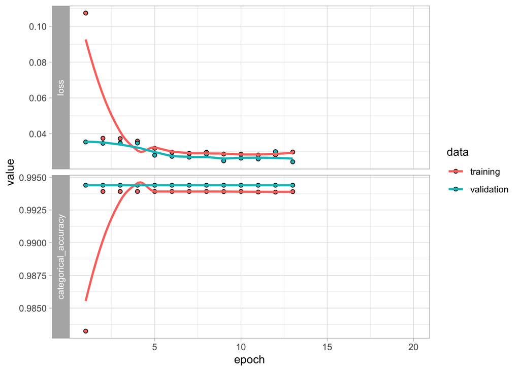

```r
fit_NN <- model %>%
  fit(fraud_train |> select(-is_fraud) |> data.matrix(), # Training features
      nn_train_target,                                   # Training labels
      epochs = 20, batch_size = 2048,                    # Training parameters
      validation_data = list(fraud_test |> select(-is_fraud) |> data.matrix(),
                             nn_test_target),            # Test data
      verbose = 0,                                       # No comments from algo
      callbacks = list(
        callback_early_stopping(monitor = "val_loss",    # Early stopping:
                                min_delta = 0.001,       # Improvement threshold
                                patience = 4,            # Nb epochs with no improvmt
                                verbose = 2              # Warning policy while training
        )
      )
  )
plot(fit_NN) + theme_light()
```

In order to save time, learning has stopped early…

Let’s fetch some predictions below.

```r
preds <- predict(model, fraud_test[1:700,] |> select(-is_fraud) |> data.matrix())
```

And show them…

```r
round(preds[1:30,])
```

```
      [,1] [,2]
 [1,]    1    0
 [2,]    1    0
 [3,]    1    0
 [4,]    1    0
 [5,]    1    0
 [6,]    1    0
 [7,]    1    0
 [8,]    1    0
 [9,]    1    0
[10,]    1    0
[11,]    1    0
[12,]    1    0
[13,]    1    0
[14,]    1    0
```

[output cut: 16 more lines]

How many frauds are detected in the test set?

```r
sum(preds[,2] == 1)
```

```
[1] 0
```

```r
sum(fraud_test$is_fraud)
```

```
[1] 4465
```

Aoutch… the algo makes the simplest bet that there is no fraud at all.

# Interpretability

Finance is often a critical discipline because it involves **money**.  
Hence, when people rely on a black-box algorithm for decision-making, they usually prefer to understand why the algorithm comes to particular conclusions.  
To do so, we need to “*white-box*” the outcome of the predictions.  
Of course, there are many ways to do that, but there is one (among others) important dichotomy:

- **global interpretability**: in this case, we seek to understand how the model works on a large set of observations, for instance, on the whole training set.
- **local interpretability**: in this case, the focus is set on one (or a few) observations and the aim is to understand how the model behaves for this particular point.

Global interpretability can also be either model-specific or model-independent.  
For instance, for tree models, **variable importance** is one way to understand when a model gives more (decision) weight to particular features. The process is the following: each time a feature is selected as a splitting variable, the resulting gain (in loss reduction) is allocated to this feature. After the growing of a tree, each feature has its total importance, i.e., the sum of all gains that it has permitted. With random forests of boosted trees, it suffices to aggregate these values (possibly discounted by a learning rate).

All tree-based packages propose these kinds of metrics. Below, we show the result from the lightGBM model that we trained earlier.

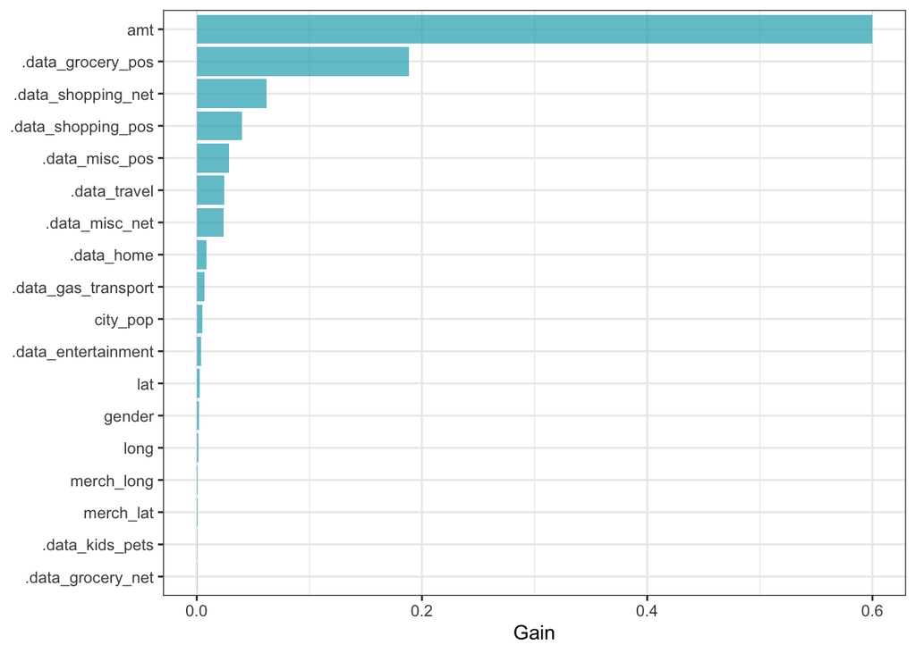

```r
lgb.importance(bst) |>
  ggplot(aes(x = Gain, y = reorder(Feature, Gain))) + geom_col(fill = "#22AABB", alpha = 0.7) +
  theme_bw() + theme(axis.title.y = element_blank())
```

The amount seems to be an important variable in the model.  
Clearly importance is concentrated in a handful of features…

In lightGBM, there is also a **local interpretation** that is proposed!

```r
LGB_intepret <- lgb.interprete(bst, fraud_test[1:700,] |> select(-is_fraud) |> data.matrix(), 1:2)
LGB_intepret
```

```
[[1]]
                Feature  Contribution
 1:      .data_misc_net -1.1148858109
 2:   .data_grocery_pos -0.2956975561
 3:  .data_shopping_net -0.1998473273
 4:                 amt -0.1473363056
 5: .data_gas_transport -0.0740643494
 6:              gender  0.0317636392
 7:            city_pop  0.0100971866
 8:  .data_shopping_pos -0.0098846304
 9:                 lat -0.0080819100
10:           merch_lat -0.0074416584
11:     .data_kids_pets -0.0063539812
12:          merch_long -0.0043236458
13:      .data_misc_pos -0.0037584725
```

[output cut: 17 more lines]

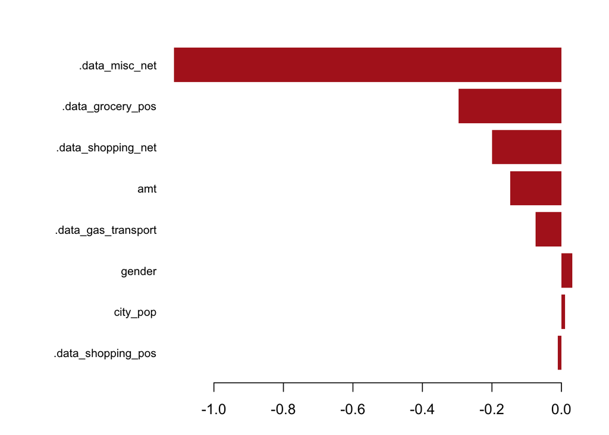

```r
lgb.plot.interpretation(
  tree_interpretation_dt = LGB_intepret[[1L]]
  , top_n = 8
)
```

Let’s try to make sense of this with actual numbers.  
The average prediction over the testing sample is 0.0075 whereas the prediction is 9.7948879^{-4}. The bars above show which features contribute the most to the discrepancy between these two values. This interpretation follows that of [**Shapley values**](https://christophm.github.io/interpretable-ml-book/shapley.html).